# US Natality Data: Causal Inference Case Study

Analysis

```r
knitr::opts_chunk$set(echo=TRUE, warning=FALSE, message=FALSE, comment=NA)

library(ggplot2)   # plot
library(dplyr)     # tables
library(readr)     # reading
library(stringr)   # strings
library(purrr)     # fp
library(tidyr)     # remove_na
library(forcats)   # factor recode
library(glmnet)    # lasso
library(grf)       # random forests
library(janitor)   # remove_constant columns
library(corrplot)  # plot correlation matrix
library(sandwich)  # robust covariance matrix
#library(sufrep)   # sufficient representations
source("make_encoder.R") # modified sufficient representations

rm(list = ls())    # reset environment
source("utils.R")  # import helpers

# The seed is set before every randomized operation throughout so results
# are consistent when rerunning cells.
```

This notebook implements a case study of some causal inference methods on an observational dataset, the [Vital Statistics Natality Birth Data](https://www.nber.org/research/data/vital-statistics-natality-birth-data). Specifically, we attempt to estimate the causal effect of a mother being a heavy smoker (vs. non-smoker) on infant birth weight, using data from 100,000 hospital births.

```r
year <- 2002
treatment <- "smoking_heavy"
```

Load data and models.

```r
# load data with original factors
natl_fname <- paste0("models/natl/natl", year, ".", treatment, ".rds")
natl <- read_rds(natl_fname)

# load data with factors encoded
natl_fname <- paste0("models/natl_rep/natl", year, ".", treatment, ".rds")
natl_rep <- read_rds(natl_fname)

# load model
train_fname <- paste0("models/causal_forests/natl", year, treatment, ".rds")
tau.forest <- read_rds(train_fname)
```

# Averate Treatment Effect

A first-pass naive attempt at making a causal estimate could simply look at a difference in means and ignore possible confounding. This would only be justified if the assignment of smoking / not smoking status was independent of the potential outcomes, i.e. the birth weight in either case. This assumption is almost certainly false, as numerous medical and socio-economic confounders could effect both smoking and health outcomes such as birth weight.

```r
difference_in_means(natl_rep, Yvar="dbirwt", Wvar="smoking_heavy")
```

```
   estimate     std.err
-230.348732    7.235986
```

```r
average_treatment_effect(tau.forest)
```

```
  estimate    std.err
-192.81906   10.58113
```

Plotting the estimated smoking probabilities against mean outcomes for non-smoking mothers, we see that among them, those who are more likely to smoke (in the counterfactual sense) have lower birth weights. This suggests that confounding factors that make mothers more likely to smoke during pregnancy also cause lower birth weights. This lines up with the fact that the difference-in-means estimator overestimated the magnitude of the effect when compared with the causal forest.

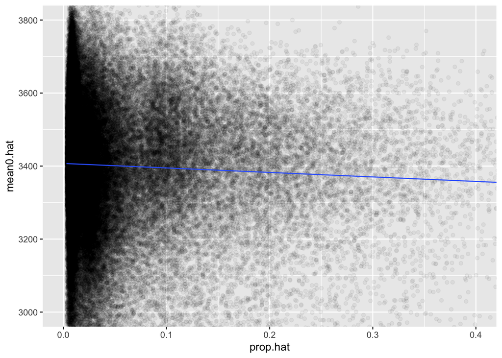

```r
tibble(prop.hat = tau.forest$W.hat,
       mean.hat = tau.forest$Y.hat,
       W = tau.forest$W.orig) %>%
  # filter to untreated (non-smokers)
  filter(W == 0) %>%
  rename(mean0.hat = mean.hat) %>%
  # plot
  ggplot(aes(x = prop.hat, y = mean0.hat)) +
  geom_point(alpha = 1/20) +
  geom_quantile(formula = y ~ x,
                quantiles = c(0.5),
                show.legend=TRUE) +
  coord_cartesian(xlim = c(0, 0.4), ylim = c(3000, 3800))
```

And the same plot with estimated treatment propensities scaled by their empirical cumulative distribution.

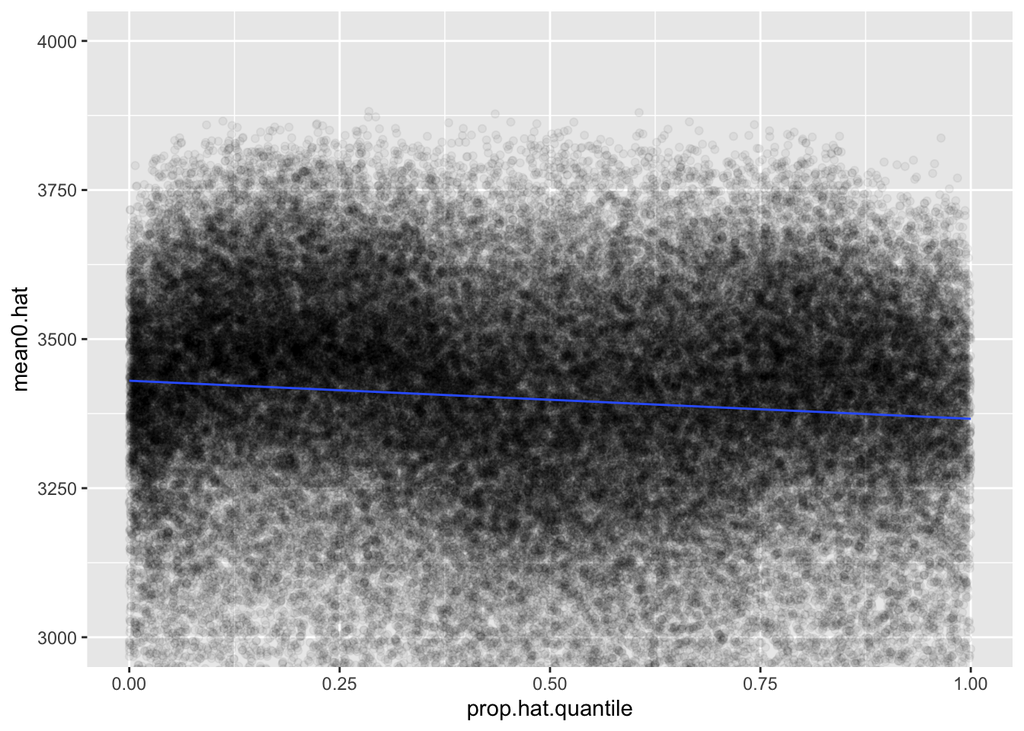

```r
tibble(prop.hat.quantile = ecdf(tau.forest$W.hat)(tau.forest$W.hat),
       mean.hat = tau.forest$Y.hat,
       W = tau.forest$W.orig) %>%
  # filter to untreated (non-smokers)
  filter(W == 0) %>%
  rename(mean0.hat = mean.hat) %>%
  # plot
  ggplot(aes(x = prop.hat.quantile, y = mean0.hat)) +
  geom_point(alpha = 1/20) +
  geom_quantile(formula = y ~ x,
                quantiles = c(0.5),
                show.legend=TRUE) +
  coord_cartesian(xlim = c(0, 1), ylim = c(3000, 4000))
```

# Averate Treatment Effect on the Treated

Since estimated treatment probabilities go very low (<1%) due to the fact that smoking is quite uncommon during pregnancy, treatment effects for some controls may not be well identified. For this reason, it can be helpful to look at the ATT (average treatment effect on the treated). Note the smaller standard error.

The point estimate of the ATT here is larger in magnitude than the ATE above, but still less than the untrustworthy difference-in-means estimate. This would seem to indicate that smoking mothers are predisposed to more severe effects of smoking on birth weight than mothers who do not smoke would be if they did.

```r
average_treatment_effect(tau.forest, target.sample = "treated")
```

```
   estimate     std.err
-214.333511    6.255447
```

# Treatment Effect Heterogeneity

The calibration test indicates we are picking up meaningful heterogeneity.

```r
test_calibration(tau.forest)
```

```
Best linear fit using forest predictions (on held-out data)
as well as the mean forest prediction as regressors, along
with one-sided heteroskedasticity-robust (HC3) SEs:

                               Estimate Std. Error t value    Pr(>t)
mean.forest.prediction         0.997368   0.029762 33.5110 < 2.2e-16 ***
differential.forest.prediction 0.784128   0.161230  4.8634 5.778e-07 ***
---
Signif. codes:  0 '***' 0.001 '**' 0.01 '*' 0.05 '.' 0.1 ' ' 1
```

The distribution of estimated conditional average treatment effect (CATE) values is solidly negative which is what we expect.

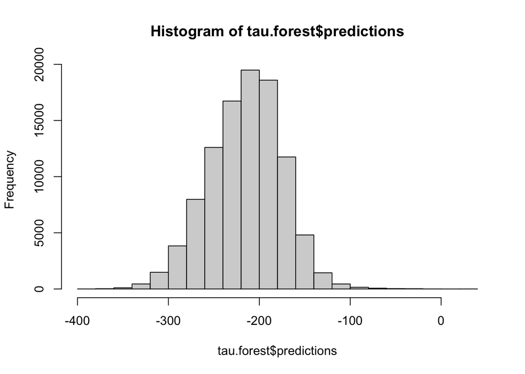

```r
hist(tau.forest$predictions)
```

Computing the best linear projections of the CATE onto all of the covariates, we see that a few variables have significant associates with the CATE. This implies that they account for heterogeneity in the treatment effect, and in the following sections we consider some of them. Note that the exact ranking is not statistically significant.

```r
set.seed(157)
tau.blp.coefs <- as.list(colnames(tau.forest$X.orig)) %>%
  # calculate best linear projections onto single variables
  map(~ best_linear_projection(tau.forest,
                               A = tau.forest$X.orig[,.x]))
names(tau.blp.coefs) <- colnames(tau.forest$X.orig)

tau.blp <- tau.blp.coefs %>%
  # filter constant vars w no coefficient
  keep(~ dim(.x)[1] == 2) %>%
  # extract into tibble rows
  imap_dfr(~ tibble(var = .y,
                    est = .x["A1", "Estimate"],
                    std = .x["A1", "Std. Error"],
                    tst = .x["A1", "t value"],
                    prb = .x["A1", "Pr(>|t|)"]))
tau.blp %>%
  arrange(prb)
```

| var | est | std | tst | prb |
| --- | --- | --- | --- | --- |
| dmage | -5.7420574 | 1.1813629 | -4.86053658 | 1.172451e-06 |
| pre4000 | -216.7189619 | 55.0972975 | -3.93338643 | 8.381429e-05 |
| nlbnl | -24.1487103 | 6.1413447 | -3.93215355 | 8.424504e-05 |
| dlivord | -23.5440148 | 6.0125998 | -3.91577949 | 9.017245e-05 |
| eclamp | 270.3253198 | 70.9446060 | 3.81037171 | 1.388416e-04 |
| dfage | -4.1642990 | 1.1807548 | -3.52681085 | 4.208147e-04 |
| phyper | 126.4953608 | 54.1380630 | 2.33653282 | 1.946547e-02 |
| ormoth.3 | 82.8263441 | 40.7343845 | 2.03332750 | 4.202208e-02 |
| dgestat | -6.5210757 | 3.3628339 | -1.93916079 | 5.248458e-02 |
| dmar | -27.7916216 | 14.4684527 | -1.92084269 | 5.475438e-02 |

[output cut: 72 more lines]

## Live Birth Order and Mother’s Age

Three variables with significant associations with heterogeneity in the treatment effect are `dlivord` (what number live birth), `nlbnl` (number of previous live births now living), and `dmage` (mother’s age). The first two are extremely correlated since `dlivord = nlbnl + nlbnd + 1` where most previous live births are still alive.

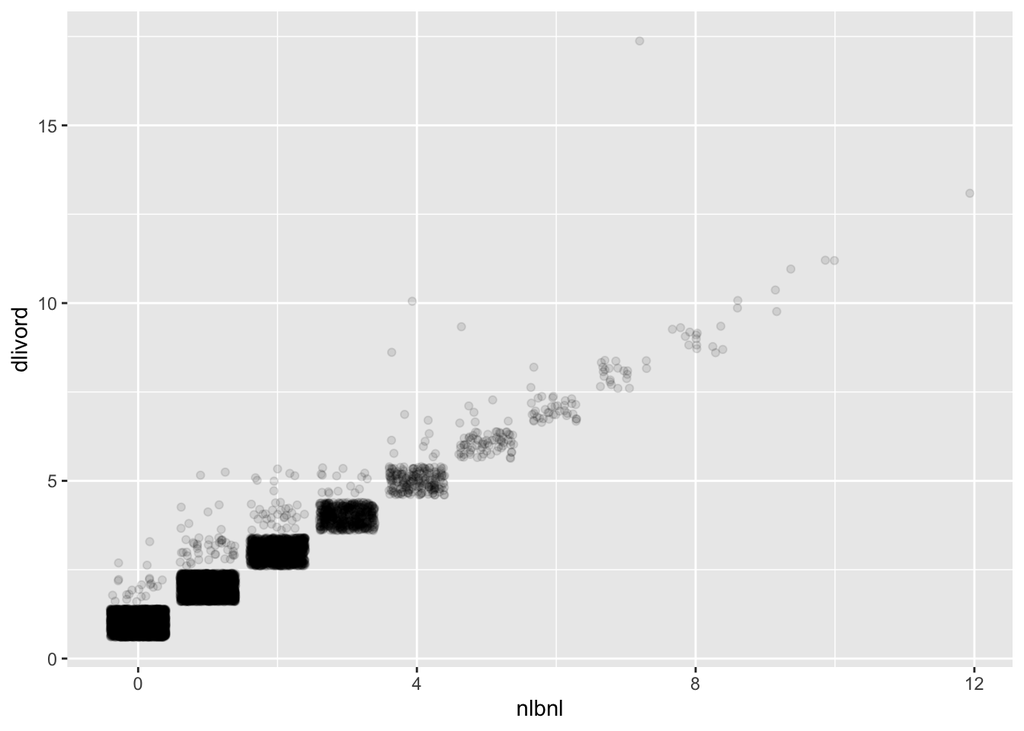

```r
natl %>%
  sample_n(10000) %>%
  ggplot(aes(x = nlbnl, y = dlivord)) +
  geom_jitter(alpha = 1/10)
```

`dlivord` and `dmage` also correlated, although less highly. Some other variables with weaker associations are also highly correlated with these, such as `dfage` the father’s age.

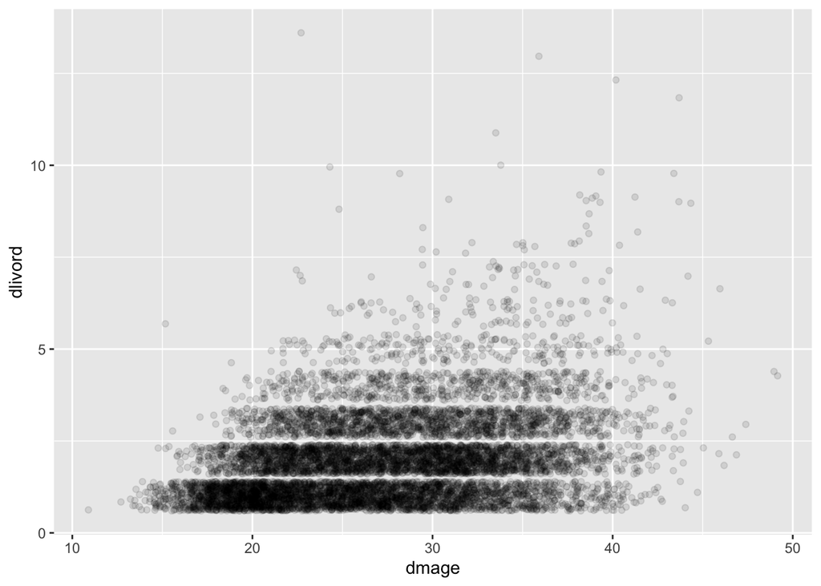

```r
natl %>%
  sample_n(10000) %>%
  ggplot(aes(x = dmage, y = dlivord)) +
  geom_jitter(alpha = 1/10, width = 0.5, heigh = 0.5)
```

Since these variables have such a high correlation with heterogeneity in the treatment effect, we can see that the estimated average effect changes significantly (in the practical sense) over their ranges.

First `dlivord`.

```r
dlivord.values <- 1:5
dlivord.table <- natl_rep$dlivord %>%
  table() %>%
  as_tibble() %>%
  rename(value = ".") %>%
  mutate(value = as.numeric(value))

as.list(dlivord.values) %>%
  map_dfr(~ average_treatment_effect(tau.forest,
                                     subset = natl$dlivord == .x,
                                     target.sample = "treated")) %>%
  mutate(value = dlivord.values,
         .before = estimate)  %>%
  inner_join(dlivord.table, by = "value") %>%
  select(value, n, estimate, std.err) %>%
  rename(dlivord = value)
```

| dlivord | n | estimate | std.err |
| --- | --- | --- | --- |
| 1 | 40632 | -187.2538 | 10.77753 |
| 2 | 32612 | -202.6679 | 10.91414 |
| 3 | 16500 | -234.6373 | 13.88215 |
| 4 | 6128 | -258.3118 | 22.62397 |
| 5 | 2151 | -286.6694 | 37.00665 |

Then `dmage`.

```r
quantiles <- 5
probs <- (0:quantiles) / quantiles

dmage.quantiles <- natl_rep$dmage %>%
  cut(quantile(., probs = probs, na.rm = TRUE),
      include.lowest = TRUE)

dmage.table <- dmage.quantiles %>%
  table() %>%
  as_tibble() %>%
  rename(value = ".")

as.list(levels(dmage.quantiles)) %>%
  map_dfr(~ average_treatment_effect(tau.forest,
                                     subset = dmage.quantiles == .x)) %>%
  mutate(value = levels(dmage.quantiles),
         .before = estimate)  %>%
  inner_join(dmage.table, by = "value") %>%
  select(value, n, estimate, std.err) %>%
  rename(dmage = value)
```

| dmage | n | estimate | std.err |
| --- | --- | --- | --- |
| [10,21] | 20243 | -155.3205 | 18.30547 |
| (21,25] | 21009 | -155.9506 | 16.90007 |
| (25,29] | 21423 | -178.7270 | 26.40490 |
| (29,33] | 20239 | -242.4721 | 28.97829 |
| (33,54] | 17086 | -247.6665 | 26.47239 |

The ATE estimates change somewhat monotonically with either `dlivord` or `dmage`, with older mothers and mothers with more previous children showing larger effects. Note that we have no way of separating the effect of smoking at a given age on birth weight from the cumulative effect of smoking prior to the pregnancy.

## Medical Risk Factors

Three covariates in the “medical risk factors” section of the natality data show significant relationships with the CATE.

Mothers with previous births over 4000g (`pre4000`) have a higher estimated causal effect.

```r
pre4000.values <- 0:1
pre4000.table <- natl_rep$pre4000 %>%
  table() %>%
  as_tibble() %>%
  rename(value = ".") %>%
  mutate(value = as.numeric(value))

as.list(pre4000.values) %>%
  map_dfr(~ average_treatment_effect(tau.forest,
                                     subset = natl_rep$pre4000 == .x)) %>%
  mutate(value = pre4000.values,
         .before = estimate)  %>%
  inner_join(pre4000.table, by = "value") %>%
  select(value, n, estimate, std.err) %>%
  rename(pre4000 = value)
```

| pre4000 | n | estimate | std.err |
| --- | --- | --- | --- |
| 0 | 98200 | -189.4038 | 10.68602 |
| 1 | 1117 | -209.5261 | 109.04933 |

However, note the very large standard error on the estimate for `pre4000`. This is due to both smoking and `pre4000` being quite rare.

```r
with(natl_rep, table(smoking_heavy, pre4000))
```

```
             pre4000
smoking_heavy     0     1
            0 91822  1064
            1  6378    53
```

Similarly, eclampsia (`eclamp`) shows a significant correlation with the CATE, but the positive sample counts here are so small these estimates aren’t meaningful.

```r
eclamp.values <- 0:1
eclamp.table <- natl_rep$eclamp %>%
  table() %>%
  as_tibble() %>%
  rename(value = ".") %>%
  mutate(value = as.numeric(value))

as.list(eclamp.values) %>%
  map_dfr(~ average_treatment_effect(tau.forest,
                                     subset = natl_rep$eclamp == .x)) %>%
  mutate(value = eclamp.values,
         .before = estimate)  %>%
  inner_join(eclamp.table, by = "value") %>%
  select(value, n, estimate, std.err) %>%
  rename(eclamp = value)
```

| eclamp | n | estimate | std.err |
| --- | --- | --- | --- |
| 0 | 98993 | -191.83051 | 10.65234 |
| 1 | 324 | -30.22477 | 163.64756 |

```r
with(natl_rep, table(smoking_heavy, eclamp))
```

```
             eclamp
smoking_heavy     0     1
            0 92576   310
            1  6417    14
```

Another medical risk factor significantly associated with the CATE is pregnancy-associated hypertension (`phyper`). The counts here are somewhat less imbalanced but the difference in ATE is still not significant compared to the standard errors.

```r
phyper.values <- 0:1
phyper.table <- natl_rep$phyper %>%
  table() %>%
  as_tibble() %>%
  rename(value = ".") %>%
  mutate(value = as.numeric(value))

as.list(phyper.values) %>%
  map_dfr(~ average_treatment_effect(tau.forest,
                                     subset = natl_rep$phyper == .x)) %>%
  mutate(value = phyper.values,
         .before = estimate)  %>%
  inner_join(phyper.table, by = "value") %>%
  select(value, n, estimate, std.err) %>%
  rename(phyper = value)
```

| phyper | n | estimate | std.err |
| --- | --- | --- | --- |
| 0 | 95478 | -195.81202 | 10.68345 |
| 1 | 3839 | -73.27828 | 68.63181 |

```r
with(natl_rep, table(smoking_heavy, phyper))
```

```
             phyper
smoking_heavy     0     1
            0 89262  3624
            1  6216   215
```

## Racial Heterogeneity

```r
mrace <- natl$mrace %>%
  table() %>%
  as_tibble() %>%
  rename(code = ".") %>%
  mutate(code = as.integer(code)) %>%
  mutate(value = case_when(
    code == 1 ~ "White",
    code == 2 ~ "Black",
    code == 3 ~ "Native American",
    code == 4 ~ "Chinese",
    code == 5 ~ "Japanese",
    code == 6 ~ "Hawaiian",
    code == 18 ~ "East Indian",
    code == 28 ~ "Korean",
    code == 48 ~ "Vietnamese",
  ), .after = code) %>%
  filter(n > 500 & !is.na(value)) # only select named races with at least 500 samples
```

```r
as.list(mrace$code) %>%
  map_dfr(~ average_treatment_effect(tau.forest,
                                     subset = natl$mrace == .x)) %>%
  mutate(value = mrace$value,
         .before = estimate) %>%
  inner_join(mrace, by = "value") %>%
  select(code, value, n, estimate, std.err)
```

| code | value | n | estimate | std.err |
| --- | --- | --- | --- | --- |
| 1 | White | 78465 | -197.8409 | 11.77907 |
| 2 | Black | 16055 | -179.9913 | 24.85794 |
| 3 | Native American | 1048 | -218.9638 | 78.96113 |
| 4 | Chinese | 676 | -192.8514 | 289.57843 |
| 18 | East Indian | 647 | -151.6351 | 17.26411 |